← Voltar ao Portal

[figure not shown]

Programa 400

# Síntese Avaliativa do Desempenho dos Programas do PPA Bahia 2024–2027

# **1 - Desempenho Global do Programa**

Este documento apresenta uma Síntese Avaliativa do Desempenho do Programa do Plano Plurianual - PPA 2024- 2027, trazendo uma visão estratégica dos seus resultados, de forma sintética, transparente e colaborativa. Serão levados em consideração o Indicador Sintético de Desempenho do Programa (ISDP), a evolução dos Indicadores de Programa, a eficácia das metas dos Indicadores de Compromisso, o desempenho da execução orçamentária-financeira e da execução física das Ações orçamentárias. O ISDP é uma síntese dessas quatro dimensões, destacando o desempenho do programa em relação aos resultados obtidos e aos esforços despendidos.  
Adicionalmente, são apresentados os principais resultados alcançados, evidenciando os avanços e conformidades dos cinco programas com melhores resultados, além das oportunidades de melhoria dos cinco, com menores resultados. Enquanto neste documento a análise abrange o programa e seus componentes de maneira sintética, nos demais relatórios, a análise detalhada evidencia o comportamento dos componentes do PPA por programas e por órgãos (https://www.ba.gov.br/seplan/monitoramento-e-avaliacao/avaliacao-do-ppa). Além desta Síntese, o [Painel BI - Boletim de Avanços e Oportunidades de Melhoria](https://app.powerbi.com/view?r=eyJrIjoiN2Q0ODliNDItZDFjZi00MGM1LTliNGEtODVmZDAwZTQ1OGEyIiwidCI6IjRjZDgzNWY0LTU0NDAtNDA4Zi05M2EzLTk3NWZjMTdjMzg0YSIsImMiOjR9) oferece informações organizadas em uma perspectiva estratégica do desempenho consolidado dos programas, detalhando, no entanto, cada componente avaliado. A análise nesta seção engloba o programa e seus componentes conforme segue:

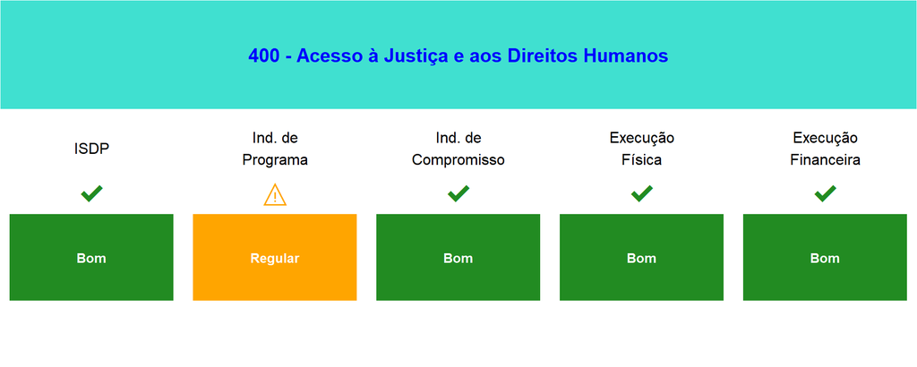

# **2 - Avanços e Conformidades no Programa**

**Indicadores de Programa:** No programa 400 - Acesso à Justiça e aos Direitos Humanos, 60% dos indicadores apresentaram evolução positiva. Destaca-se o indicador 2134, que monitora o número de pessoas com deficiência que concluíram a graduação, apresentando uma evolução de 94,78%. Essa melhora é atribuída à ampliação da estrutura e capacidade institucional. O número de concluintes com deficiência cresceu de 230, em 2021, para 504, em 2023, com uma leve queda em 2024, mas ainda assim mantendo um volume expressivo. Esse crescimento reflete os avanços nas políticas públicas de inclusão e permanência no ensino superior, como a ampliação de ações afirmativas, melhorias nas condições de acessibilidade e o fortalecimento de programas de apoio acadêmico e social. Outro indicador relevante do programa 400 é o 2168, que mede o índice de subregistro civil de nascidos vivos na Bahia, que teve uma evolução de -55,73%. Essa melhoria se deve à ampliação dos serviços de registro civil, que resultou em um nível mais baixo de subregistro no estado. Um índice menor indica maior efetividade das ações e fortalece a garantia do direito à identidade e à cidadania desde o nascimento.  
**Indicadores de Compromisso:** No programa 400 - Acesso à Justiça e aos Direitos Humanos, 69,5% dos indicadores de compromisso foram avaliados com desempenho bom ou ótimo. Dentre esses, destaca-se o indicador que mede o ‘Número de municípios atendidos pelos serviços em Direitos Humanos’, que atingiu 115,15%. Esse resultado é atribuível às diversas oportunidades, parcerias e adesões que possibilitaram a implementação das ações, com ênfase na colaboração estabelecida com a Fundação Luiz Eduardo Magalhães (FLEM), a qual possibilitou a ampliação do atendimento e a interiorização dos serviços por meio das Caravanas de Direitos Humanos. Espera-se que, até 2026, esse número continue a crescer. Outro indicador relevante é o ‘Número de denúncias de violações de direitos humanos recebidas pela SJDH’, que alcançou 127,63%. Esse aumento pode ser explicado pela ampliação da estrutura e capacidade institucional, especialmente com a nova estruturação física da Ouvidoria na SJDH em 2024, que incluiu um servidor dedicado exclusivamente ao recebimento de manifestações. Essa mudança resultou em um incremento nas denúncias, reclamações, pedidos de informação e elogios provenientes dos canais de comunicação disponíveis. A expectativa é que, nos próximos anos, esse volume continue a crescer, evidenciando a importância da atuação da Ouvidoria no acolhimento, registro, acompanhamento e encaminhamento das manifestações recebidas.  
**Ações Orçamentárias:** Em relação à execução financeira do Programa 400 - Acesso à Justiça e aos Direitos Humanos, 61,9% das ações foram classificadas como de bom ou ótimo desempenho. No que diz respeito à execução física desse mesmo programa, 87% das ações obtiveram uma classificação semelhante. Esse resultado é, por exemplo, refletido nas ações do Programa 400 - Acesso à Justiça e aos Direitos Humanos, onde a Ação 2170 - Apoio Técnico e Financeiro a Entidades na Defesa dos Direitos Humanos apresentou uma execução financeira classificada como Boa e uma execução física classificada como Ótima. Da mesma forma, a Ação 4196 - Atendimento Especializado para Promoção de Direitos e Combate às Violências contra a População LGBTQIAPN+ demonstrou uma execução financeira e física classificadas como Ótimas.

# **3 - Oportunidade de Melhoria no Programa**

**Indicadores de Programa:** No Programa 400 - Acesso à Justiça e aos Direitos Humanos, 40% dos indicadores apresentaram evolução negativa, destacando-se o indicador 2166, que mede o número de notificações de violência interpessoal e autoprovocada contra pessoas idosas, que aumentou em 113,63%. Essa elevação pode ser atribuída, em parte, à melhoria nos mecanismos de notificação e ao fortalecimento da rede de proteção, além de um maior engajamento dos profissionais na documentação desses casos. Portanto, o aumento no número de notificações não implica necessariamente um incremento na violência, mas pode refletir uma melhor identificação, registro e visibilidade dos casos, o que fortalece o monitoramento e o planejamento de políticas públicas voltadas à proteção dos idosos.  
**Indicadores de Compromisso:** No programa 400 - Acesso à Justiça e aos Direitos Humanos, 5,6% dos indicadores de compromisso foram classificados como apresentando desempenho baixo ou muito baixo. Além disso, outros 5,6% dos indicadores também foram categorizados como de desempenho indeterminado, refletindo a complexidade da avaliação desses compromissos. Por outro lado, 13,9% dos indicadores foram considerados não aptos para avaliação, o que pode ser atribuído à falta de dados ou à inexistência de critérios claros para mensuração. Um dos indicadores que exemplifica a situação do programa é o ‘Número de registros civis alterados pelo procedimento de reconhecimento de paternidade’, que atingiu apenas 26,25%. Essa baixa taxa pode ser justificada pela execução de ações que ainda não estão plenamente implementadas. A Secretaria de Justiça e Direitos Humanos (SJDH), em parceria com o Ministério Público, está desenvolvendo o Projeto Paternidade Responsável, que tem como objetivo aumentar o número de reconhecimentos formais de paternidade, garantindo o direito à filiação para crianças e adolescentes. Para isso, uma parceria foi firmada em abril de 2025, visando a contratação de uma empresa especializada para realizar exames de investigação de paternidade. Por fim, outro indicador relevante dentro do programa é a ‘Taxa de cobertura de oferta do serviço de interpretação de Libras nos órgãos públicos estaduais’, que atualmente se encontra em 50%. Essa taxa é influenciada por dificuldades de âmbito institucional. Um dos principais obstáculos à ampliação da cobertura dos serviços de interpretação de Libras para pessoas com surdez é a autonomia que as diferentes secretarias possuem para decidir sobre a implantação do serviço em suas respectivas estruturas, refletindo a necessidade de maior integração e coordenação entre os órgãos públicos.  
**Ações Orçamentárias:** Por outro lado, em relação à execução financeira do Programa 400 - Acesso à Justiça e aos Direitos Humanos, 33,3% das ações apresentaram desempenho classificado como baixo ou muito baixo. No que se refere à execução física, 13% das ações do programa também tiveram desempenho considerado baixo ou muito baixo. Este cenário foi influenciado por algumas ações em particular.

Desenvolvido por: DAP – Diretoria de Avaliação de Políticas Públicas